# **1. Regression and model validation**

───▄▀▀▀▄▄▄▄▄▄▄▀▀▀▄───  
───█▒▒░░░░░░░░░▒▒█───  
────█░░█░░░░░█░░█────  
─▄▄──█░░░▀█▀░░░█──▄▄─  
█░░█─▀▄░░░░░░░▄▀─█░░█

# 1.1 *Data wrangling (5p)*

first session: creating a data set.  
data source: survey of Approaches to Learning…

Kimmo Vehkalahti: ASSIST 2014 - Phase 3 (end of Part 2), N=183 Course: Johdatus yhteiskuntatilastotieteeseen, syksy 2014 (Introduction to Social Statistics, fall 2014 - in Finnish), international survey of Approaches to Learning, made possible by Teachers’ Academy funding for KV in 2013-2015.

# 1.2 *Data analysis (2p)*

Dataset structure: 7 variables and 166 observations  
Several questions were asked in the survey, three learning approaches resulted from the combination of similar questions (deep, surfing and strategical approach).

```r
data <-learning2014 <- read.csv("~/GitHub/IODS-project/IODS-project/data_AKMV/learning2014.csv")
#data<-read.csv("learning2014.csv")
str(data)
```

```
## 'data.frame':    166 obs. of  8 variables:
##  $ X       : int  1 2 3 4 5 6 7 8 9 10 ...
##  $ gender  : chr  "F" "M" "F" "M" ...
##  $ Age     : int  53 55 49 53 49 38 50 37 37 42 ...
##  $ attitude: num  3.7 3.1 2.5 3.5 3.7 3.8 3.5 2.9 3.8 2.1 ...
##  $ deep    : num  3.58 2.92 3.5 3.5 3.67 ...
##  $ stra    : num  3.38 2.75 3.62 3.12 3.62 ...
##  $ surf    : num  2.58 3.17 2.25 2.25 2.83 ...
##  $ Points  : int  25 12 24 10 22 21 21 31 24 26 ...
```

## a) Variables (mean and range) - (3p)

Gender: 110 are female (F) and 56 are men(M)  
Age: from 17 to 55 years old (25 is the mean)  
Attitude: 3.2 (1.4-5)  
Deep: 3.68 (1.583-4.917)  
Strategy: 3.121 (1.250 - 5)  
Surfing: 2.787 (1.583-4.333)  
Points: 22.72 (7 - 33)

```r
library(GGally)
```

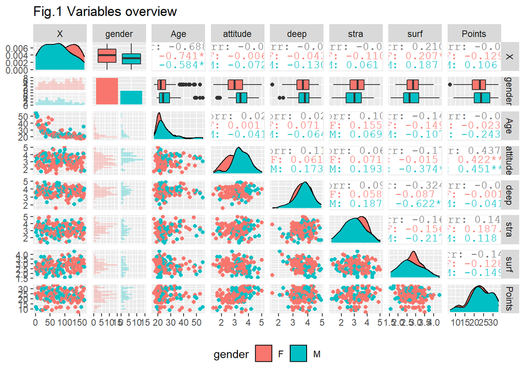

```r
library(ggplot2)
ggpairs(data, mapping = aes(colour=gender), legend = 1,
        title="Fig.1 Variables overview",
        lower = list(combo = wrap("facethist",size=0.1, bins = 20, alpha=0.3)))+
        theme(legend.position="bottom")
```

Age of the participants, deep learning approach and the points obtained in the final test are non-normal distributed (Fig.1).

## b) Choosing three variables as explanatory variables (4p + 3p)

LINNEAR REGRESSION MODEL

```r
mod1<-lm(Points~Age+attitude+deep+surf+stra+gender, data=data)
summary(mod1)
```

```
##
## Call:
## lm(formula = Points ~ Age + attitude + deep + surf + stra + gender,
##     data = data)
##
## Residuals:
##      Min       1Q   Median       3Q      Max
## -17.4506  -3.2479   0.3879   3.5243  11.4820
##
## Coefficients:
##             Estimate Std. Error t value Pr(>|t|)
## (Intercept) 18.30246    5.25723   3.481 0.000644 ***
## Age         -0.09607    0.05396  -1.780 0.076929 .
## attitude     3.44300    0.59776   5.760 4.24e-08 ***
## deep        -1.04279    0.78438  -1.329 0.185606
## surf        -1.10891    0.84467  -1.313 0.191132
## stra         0.95871    0.55150   1.738 0.084083 .
## genderM     -0.05858    0.92985  -0.063 0.949845
## ---
## Signif. codes:  0 '***' 0.001 '**' 0.01 '*' 0.05 '.' 0.1 ' ' 1
##
## Residual standard error: 5.265 on 159 degrees of freedom
## Multiple R-squared:  0.2312, Adjusted R-squared:  0.2021
## F-statistic: 7.967 on 6 and 159 DF,  p-value: 1.599e-07
```

attitude, age and strategy are the most relevant variables

```r
mod2<-lm(Points~Age+attitude+stra, data=data)
summary(mod2)
```

```
##
## Call:
## lm(formula = Points ~ Age + attitude + stra, data = data)
##
## Residuals:
##      Min       1Q   Median       3Q      Max
## -18.1149  -3.2003   0.3303   3.4129  10.7599
##
## Coefficients:
##             Estimate Std. Error t value Pr(>|t|)
## (Intercept) 10.89543    2.64834   4.114 6.17e-05 ***
## Age         -0.08822    0.05302  -1.664   0.0981 .
## attitude     3.48077    0.56220   6.191 4.72e-09 ***
## stra         1.00371    0.53434   1.878   0.0621 .
## ---
## Signif. codes:  0 '***' 0.001 '**' 0.01 '*' 0.05 '.' 0.1 ' ' 1
##
## Residual standard error: 5.26 on 162 degrees of freedom
## Multiple R-squared:  0.2182, Adjusted R-squared:  0.2037
## F-statistic: 15.07 on 3 and 162 DF,  p-value: 1.07e-08
```

The equation obtained is:  
points=10.89 + 3.48*attitude + 1*strategy approach - 0.08*age (+ or - 5.26)

With 20.3% of accuracy we can calculate the obtained points in the final evaluation by the equation showed in model 2 (mod2), Attitude is the most important variable to get more points. The importance of this model is based on the fact that we can explain and detect the most significant variables in the learning process rather than predict the points.

## c) Diagnostic plots of the model (3p)

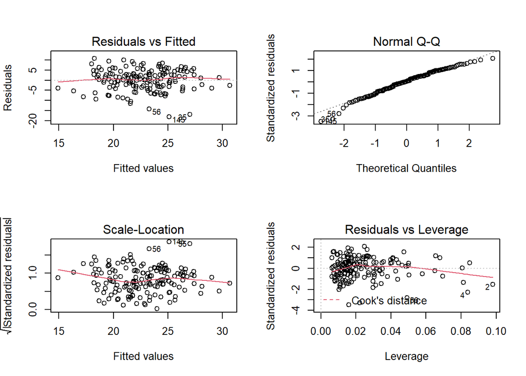

```r
#Residuals vs Fitted values, Normal QQ-plot and Residuals vs Leverage
par(mfrow=c(2,2))
plot(mod2)
```

The graphs are not fancy but important, it shows that the accuracy reported in the model is trustworthy.